# SLEEP AND LIFESTYLE ANALYSIS

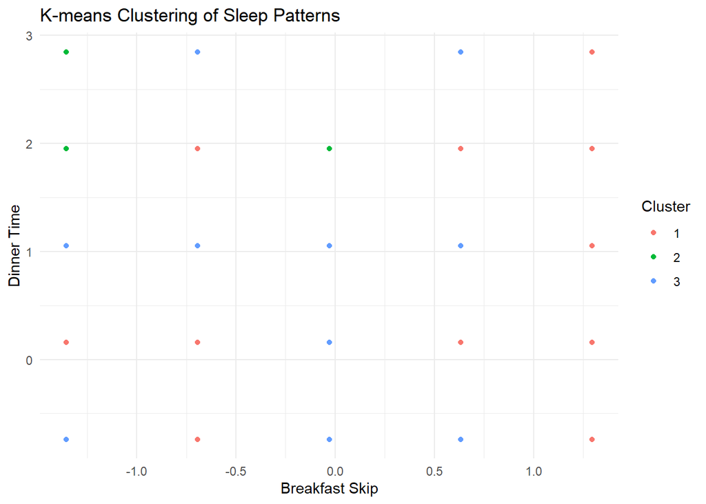

```r
kmeans_model <- kmeans(normalized_data, centers = 3, nstart = 10)

normalized_data$cluster <- as.factor(kmeans_model$cluster)

ggplot(normalized_data, aes(x = BreakfastSkip, y = DinnerTime, color = cluster)) +
  geom_point() +
  labs(title = "K-means Clustering of Sleep Patterns",
       x = "Breakfast Skip",
       y = "Dinner Time",
       color = "Cluster") +
  theme_minimal()
```

**Plotting the 3d scatterplot for the clusters**

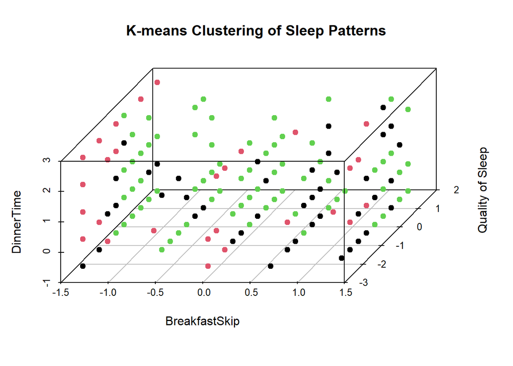

```r
normalized_data$cluster <- as.factor(kmeans_model$cluster)

scatterplot3d(normalized_data$BreakfastSkip, normalized_data$QualityOfSleep, normalized_data$DinnerTime,
              color = as.numeric(normalized_data$cluster),
              pch = 19,
              main = "K-means Clustering of Sleep Patterns",
              xlab = "BreakfastSkip",
              ylab = "Quality of Sleep",
              zlab = "DinnerTime",
              angle = 55)
```

**Plotting the Pair Plots for these normalized columns**

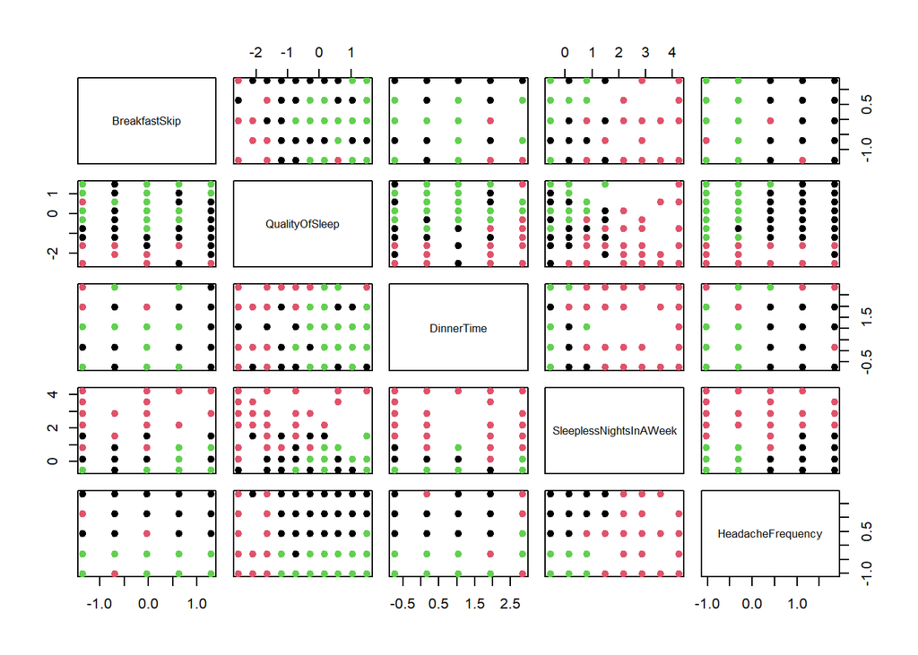

```r
normalized_data$cluster <- as.factor(kmeans_model$cluster)

normalized_subset <- normalized_data[, c("BreakfastSkip", "QualityOfSleep", "DinnerTime", "SleeplessNightsInAWeek", "cluster", "HeadacheFrequency")]

pairs(normalized_subset[, -5], col = normalized_subset$cluster, pch = 19)
```

**Normalizing the columns Breakfast Skip, Quality Of Sleep, Dinner Time, Headache Frequency , Physical Activity Level, and Stress Level**

```r
data_subset <- encoded_data1[, c("BreakfastSkip", "QualityOfSleep", "PhysicalActivityLevel","StressLevel","HeadacheFrequency", "DinnerTime")]

normalized_data <- scale(data_subset)

head(normalized_data)
```

```
##   BreakfastSkip QualityOfSleep PhysicalActivityLevel StressLevel
## 1    -1.3559086     -1.1981951             1.2269562   1.4444408
## 2    -0.6930505      0.6032936            -0.4554280   1.4444408
## 3    -1.3559086     -0.2974508            -0.4554280   0.2652888
## 4    -0.6930505      0.1529214            -0.4554280   1.4444408
## 5    -0.0301923      1.5040379             1.6475522  -2.0930151
## 6    -0.6930505      0.6032936             0.3857641   1.4444408
##   HeadacheFrequency DinnerTime
## 1         -1.022496 -0.7385312
## 2         -1.022496  0.1577265
## 3         -0.305710  1.0539842
## 4         -1.022496  0.1577265
## 5         -0.305710  1.0539842
## 6          0.411076 -0.7385312
```

**Applying a decision tree model on the normalized columns**

```r
library(caTools)
normalized_data_df <- as.data.frame(normalized_data)

set.seed(123)

split <- sample.split(normalized_data_df$QualityOfSleep, SplitRatio = 0.8)

train_data <- subset(normalized_data_df, split == TRUE)

test_data <- subset(normalized_data_df, split == FALSE)
```

```r
library(rpart)
normalized_data_df <- as.data.frame(normalized_data)

model_tree <- rpart(QualityOfSleep ~ PhysicalActivityLevel + BreakfastSkip + StressLevel + HeadacheFrequency + DinnerTime, data = train_data)
```

**Plotting the decision tree model created above**

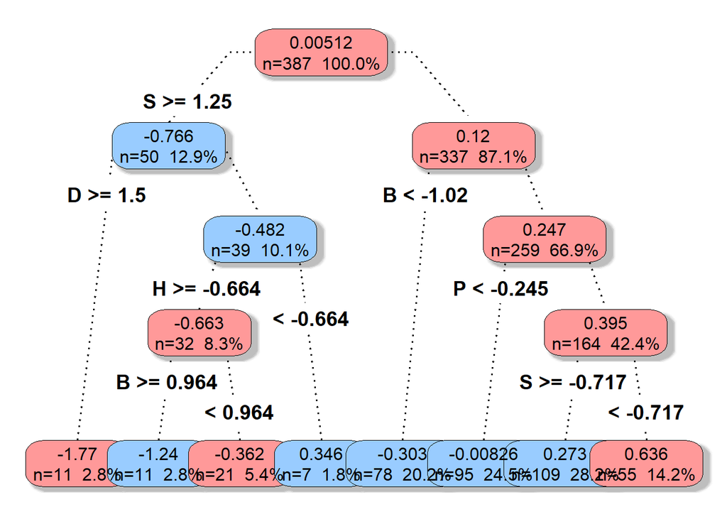

```r
library(rpart.plot)

prp(model_tree,
    box.col = c("#FF9999", "#99CCFF"),
    branch.lty = 3,
    branch.lwd = 2,
    split.cex = 1.2,
    extra = 101,
    shadow.col = "gray",
    varlen = 1,
    faclen = 1,
    tweak = 1.5,

    branch = 0.6,
    type = 4,
    digits = 3,

    fallen.leaves = TRUE,
    #widths = c(0.6, 0.9),
    #just = c("left", "left")
)
```

**Applying a Random Forest model on the normalized columns**

```r
library(randomForest)
model_rf <- randomForest(QualityOfSleep ~ PhysicalActivityLevel + BreakfastSkip + StressLevel + HeadacheFrequency + DinnerTime, data = train_data)

print(model_rf)
```

```
##
## Call:
##  randomForest(formula = QualityOfSleep ~ PhysicalActivityLevel +      BreakfastSkip + StressLevel + HeadacheFrequency + DinnerTime,      data = train_data)
##                Type of random forest: regression
##                      Number of trees: 500
## No. of variables tried at each split: 1
##
##           Mean of squared residuals: 0.8912815
##                     % Var explained: 10.47
```

**Getting the accuracy metrics of the Random Forest Model**

```r
predictions <- predict(model_rf, test_data)

actual_values <- encoded_data1$QualityOfSleep

MAE <- mean(abs(actual_values - predictions))
MSE <- mean((actual_values - predictions)^2)
RMSE <- sqrt(MSE)
actual_mean <- mean(actual_values)
total_sum_of_squares <- sum((actual_values - actual_mean)^2)
residual_sum_of_squares <- sum((actual_values - predictions)^2)
R_squared <- 1 - (residual_sum_of_squares / total_sum_of_squares)

cat("\nMean Absolute Error (MAE):", MAE, "\n")
```

```
##
## Mean Absolute Error (MAE): 6.643251
```

```r
cat("Mean Squared Error (MSE):", MSE, "\n")
```

```
## Mean Squared Error (MSE): 49.05329
```

```r
cat("Root Mean Squared Error (RMSE):", RMSE, "\n")
```

```
## Root Mean Squared Error (RMSE): 7.003806
```

```r
cat("R-squared:", R_squared, "\n")
```

```
## R-squared: -8.970371
```

**Performing hypothesis testing on all the columns to identify which variables are affecting sleep quality and which do not seem to affect the quality of sleep**

1. Hypothesis - There is a relationship between skipping breakfast and headache frequency among individuals.

```r
data_subset <- encoded_data1[, c("BreakfastSkip", "HeadacheFrequency")]

model <- lm(HeadacheFrequency ~ BreakfastSkip, data = data_subset)
summary(model)
```

```
##
## Call:
## lm(formula = HeadacheFrequency ~ BreakfastSkip, data = data_subset)
##
## Residuals:
##     Min      1Q  Median      3Q     Max
## -1.4632 -1.4068  0.5368  0.6119  2.6119
##
## Coefficients:
##               Estimate Std. Error t value Pr(>|t|)
## (Intercept)    2.36926    0.14325  16.539   <2e-16 ***
## BreakfastSkip  0.01879    0.04216   0.446    0.656
## ---
## Signif. codes:  0 '***' 0.001 '**' 0.01 '*' 0.05 '.' 0.1 ' ' 1
##
## Residual standard error: 1.396 on 481 degrees of freedom
## Multiple R-squared:  0.000413,   Adjusted R-squared:  -0.001665
## F-statistic: 0.1987 on 1 and 481 DF,  p-value: 0.6559
```

**Correlation between Headache Frequency and Breakfast Skip**

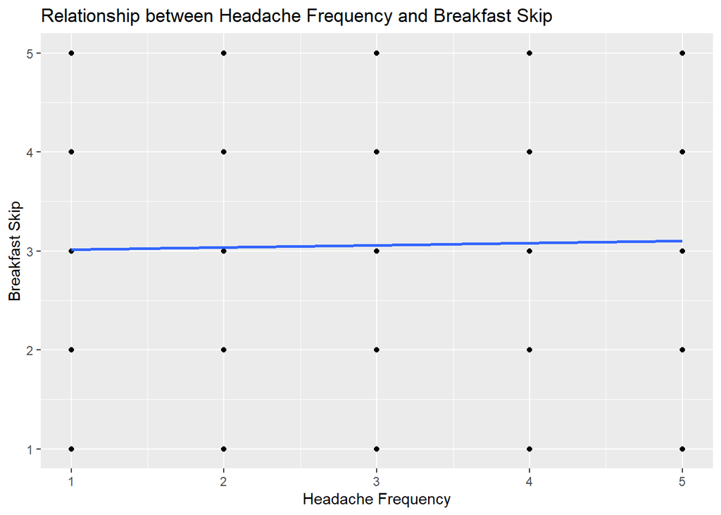

```r
ggplot(data_subset, aes(x = HeadacheFrequency, y = BreakfastSkip)) +
  geom_point() +
  geom_smooth(method = "lm", se = FALSE) +
  labs(x = "Headache Frequency", y = "Breakfast Skip") +
  ggtitle("Relationship between Headache Frequency and Breakfast Skip")
```

Null Hypothesis (H0): There is no association between skipping breakfast and headache frequency among individuals.

In this case, the p-value for “Skipping Breakfast” is quite large (0.6559), indicating that it is highly likely to observe the estimated coefficient value if the true coefficient were zero (i.e., if there were no relationship between skipping breakfast and headache frequency). Therefore, we accept the null hypothesis.

In simpler terms, the statistical evidence suggests that there is no significant relationship between Skipping Breakfast and Headache Frequency.

2. Hypothesis - There is a relationship between the time of dinner and headache frequency among individuals.

```r
data_subset <- encoded_data1[, c("DinnerTime", "HeadacheFrequency")]

model <- lm(HeadacheFrequency ~ DinnerTime, data = data_subset)

summary(model)
```

```
##
## Call:
## lm(formula = HeadacheFrequency ~ DinnerTime, data = data_subset)
##
## Residuals:
##     Min      1Q  Median      3Q     Max
## -1.4543 -1.4193  0.5457  0.5807  2.5807
##
## Coefficients:
##             Estimate Std. Error t value Pr(>|t|)
## (Intercept) 2.410534   0.121867  19.780   <2e-16 ***
## DinnerTime  0.008754   0.057011   0.154    0.878
## ---
## Signif. codes:  0 '***' 0.001 '**' 0.01 '*' 0.05 '.' 0.1 ' ' 1
##
## Residual standard error: 1.397 on 481 degrees of freedom
## Multiple R-squared:  4.901e-05,  Adjusted R-squared:  -0.00203
## F-statistic: 0.02358 on 1 and 481 DF,  p-value: 0.878
```

**Correlation between Headache Frequency and Dinner Time**

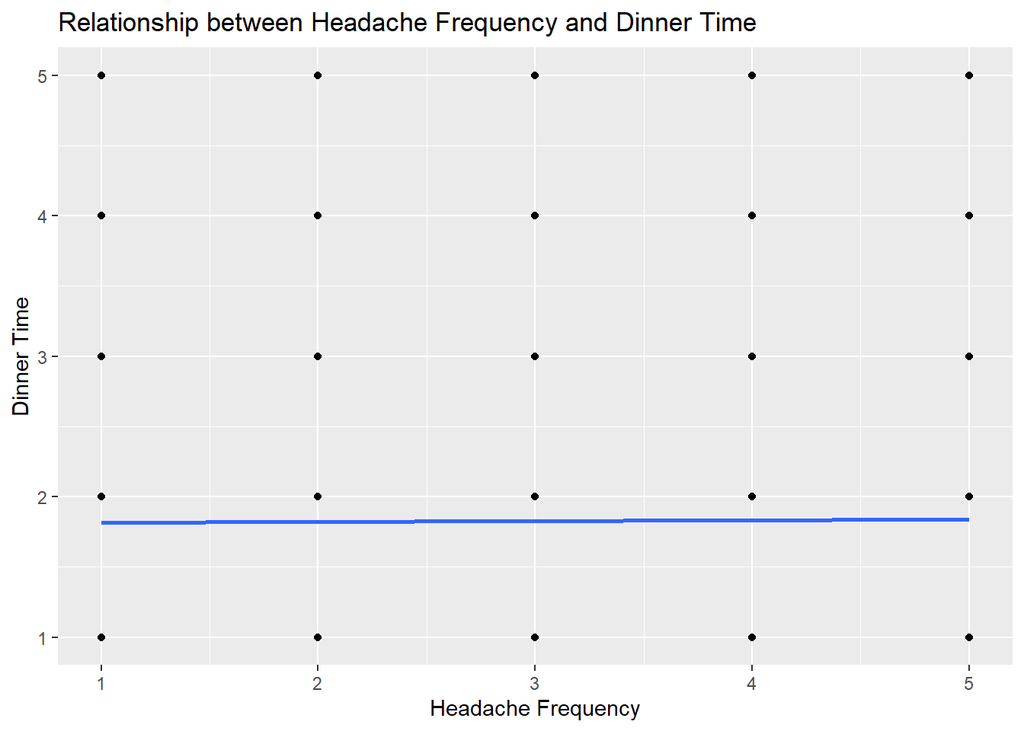

```r
ggplot(data_subset, aes(x = HeadacheFrequency, y = DinnerTime)) +
  geom_point() +
  geom_smooth(method = "lm", se = FALSE) +
  labs(x = "Headache Frequency", y = "Dinner Time") +
  ggtitle("Relationship between Headache Frequency and Dinner Time")
```

Null Hypothesis (H0): There is no association between the time of dinner and headache frequency among individuals.

In this case, the p-value for “DinnerTime” is quite large (0.878), indicating that it is highly likely to observe the estimated coefficient value if the true coefficient were zero (i.e., if there were no relationship between Dinner Time and headache frequency). Therefore, we accept the null hypothesis.

In simpler terms, the statistical evidence suggests that there is no significant relationship between Dinner Time and Headache Frequency.